# Peer Assessment

Ricardo Alcaraz Fraga

1/8/2020

This document is made as requested by Roger D. Peng as part of the Coursera course **Reproducible Research**. I’m going to explain the procedure I followed in order to answer to the assessment’s questions.

## Reading the data

As a way of organizing the project files, I designed a folder named **Data** in which I always store the data that is going to be used in the project.

```r
data <- read.csv('/home/ricardo/Escritorio/PeerAssessment/Data/activity.csv')
head(data)
```

```
##   steps       date interval
## 1    NA 2012-10-01        0
## 2    NA 2012-10-01        5
## 3    NA 2012-10-01       10
## 4    NA 2012-10-01       15
## 5    NA 2012-10-01       20
## 6    NA 2012-10-01       25
```

## What is mean total number of steps taken per day?

The first question we are going to answer in this question is: *how many steps were taken by day?* This can be seen in the next histogram.

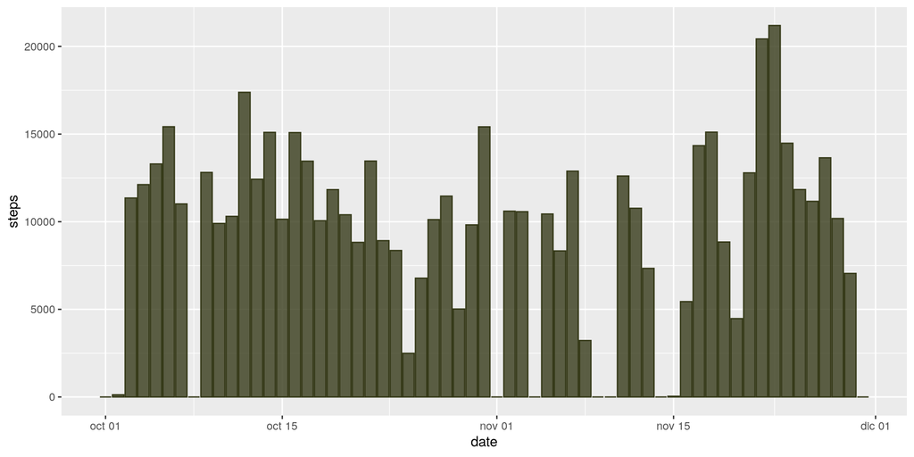

There were days in which no data was registered for the number of steps, these were treated as if no steps were taken that day.  
The second question answered in this section is *what is the mean and median of the numbers of steps taken each day?*

```
##          date       mean median
## 1  2012-10-01  0.0000000     NA
## 2  2012-10-02  0.4375000      0
## 3  2012-10-03 39.4166667      0
## 4  2012-10-04 42.0694444      0
## 5  2012-10-05 46.1597222      0
## 6  2012-10-06 53.5416667      0
## 7  2012-10-07 38.2465278      0
## 8  2012-10-08  0.0000000     NA
## 9  2012-10-09 44.4826389      0
## 10 2012-10-10 34.3750000      0
## 11 2012-10-11 35.7777778      0
## 12 2012-10-12 60.3541667      0
## 13 2012-10-13 43.1458333      0
## 14 2012-10-14 52.4236111      0
```

[output cut: 47 more lines]

As you can see, the median value is not that helpful because of all the NAs and 0s on the data, still, the mean is indeed helpful and this numbers compliment really good the histogram previously shown.

## What is the average daily activity pattern?

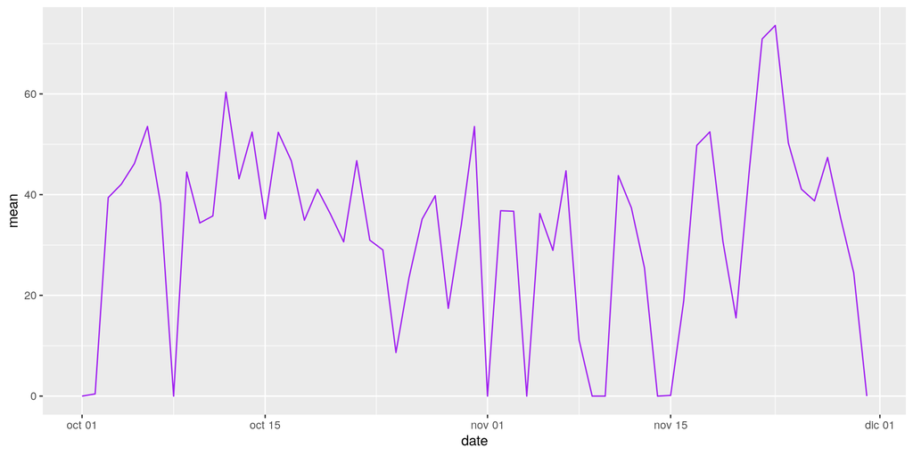

Continuing with this section I’ll show what’s the interval with the greatest mean of steps.

```
##     interval     mean
## 104      835 206.1698
```

## Imputing missing values

As we’ve seen, there are a lot of NAs values that may bias our measurements means and medians. Let’s look at how many NA values are there in the data set.

```r
len <- length(data$steps)
print(paste0('Total of observations in the data set: ', len))
```

```
## [1] "Total of observations in the data set: 17568"
```

```r
nas <- sum(is.na(data$steps))
print(paste0('Total of NA values in the data set: ', nas))
```

```
## [1] "Total of NA values in the data set: 2304"
```

```r
perc <- nas * 100 / len
print(paste0(paste0('Percentage of NA values: ', perc), '%'))
```

```
## [1] "Percentage of NA values: 13.1147540983607%"
```

To fill in the NA values, we were told to create a strategy for imputing this values. We are going to implement a strategy in which we fill the gaps with the mean for that 5-minute interval.

```r
nas_ind <- which(is.na(data$steps))

for(index in nas_ind){
  row_index_frame <- which(frame$interval == data[index, 'interval'])
   data$steps[index] <- frame[row_index_frame, 'mean']
}

print(head(data))
```

```
##       steps       date interval
## 1 1.7169811 2012-10-01        0
## 2 0.3396226 2012-10-01        5
## 3 0.1320755 2012-10-01       10
## 4 0.1509434 2012-10-01       15
## 5 0.0754717 2012-10-01       20
## 6 2.0943396 2012-10-01       25
```

As we can see from the head from the data, there are now no NA values! Now let’s re-compute the histogram of the total of steps taken each day, as well as the mean and median and we’ll see how different it looks.

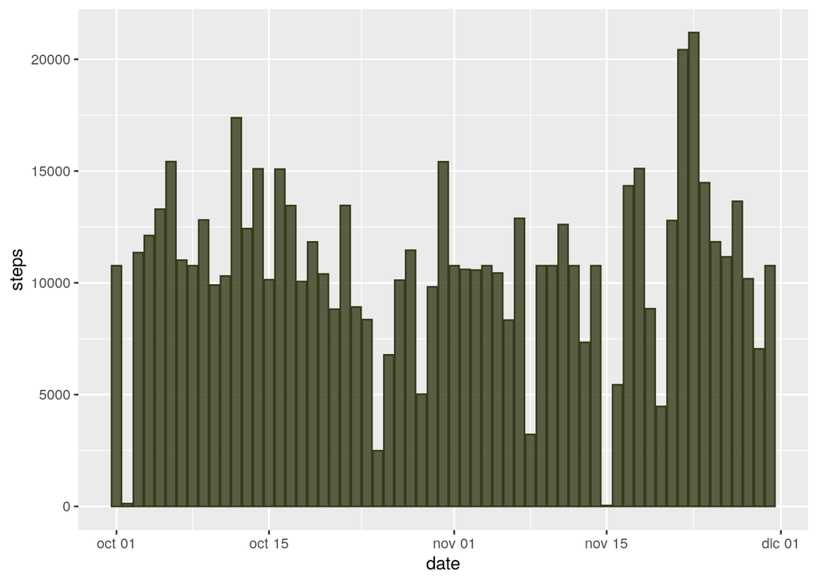

```
##          date       mean   median
## 1  2012-10-01 37.3825996 34.11321
## 2  2012-10-02  0.4375000  0.00000
## 3  2012-10-03 39.4166667  0.00000
## 4  2012-10-04 42.0694444  0.00000
## 5  2012-10-05 46.1597222  0.00000
## 6  2012-10-06 53.5416667  0.00000
## 7  2012-10-07 38.2465278  0.00000
## 8  2012-10-08 37.3825996 34.11321
## 9  2012-10-09 44.4826389  0.00000
## 10 2012-10-10 34.3750000  0.00000
## 11 2012-10-11 35.7777778  0.00000
## 12 2012-10-12 60.3541667  0.00000
## 13 2012-10-13 43.1458333  0.00000
## 14 2012-10-14 52.4236111  0.00000
```

[output cut: 47 more lines]

What a change! Everything looks a lot useful now (of course, if we assume our imputing strategy is good enough to generate better insight from the data).

## Are there differences in activity patterns between weekdays and weekends?

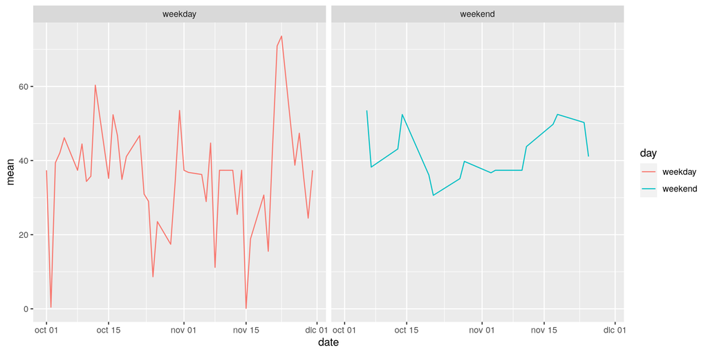